# Exploring the BRFSS data

## Setup

### Load packages

```r
library(ggplot2)
library(dplyr)
```

### Load data

```r
load("brfss2013.RData")
```

## Part 1: Data

The BRFSS 2013 dataset is a survey which samples a selection of the United States population across all 50 states. The survey contains findings from non-institutionalised correspondents and those that are 18 or older and is “designed to measure behavioral risk factors” (Source: BRFSS2013 codebook).

Therefore, we cannot use this information to infer information about children within the US population, or adults within prison, for example.

The survey uses random sampling (Source: BRFSS2013 codebook) and interviews take place over the telephone, both via landline and cellular. With this in mind, it is worth noting that the survey will not contain any insights about either participants in the survey or those within the general population that do not have telephones.

Bearing the above in mind, given the large sample size and use of random sampling, we can take this sample as typical of the population from which it is drawn: That is non-institutionalised adults aged 18 and over within the United States.

Finally, as this data is effectively observational and not a designed experiment where for example, we would assign particpants to two groups (a control and test), we cannot imply causation with any findings we might discover.

## Part 2: Research questions

**Research question 1:** My first question is: Is there a relationship between income and number of days of poor (specified as ‘not good’) health?

Within the data, there are two numerical variables associated with health; Number Of Days Physical Health Not Good and Number Of Days Mental Health Not Good. Alongside this, there is also a categorical variable which contains income bands (Income Level).

I would like to understand if mental or physical health illness, or both, are more prevalent for income levels, as well as what the average looks like for survey participants. It is worth noting that we cannot imply causation, but we can still investigation the correlation between income level and mental/physical health.

**Research question 2:**

How much healthy food is consumed per state?

We know that even though levels of obesity are levelling off, rates are still “alarmingly higher” compared to a generation ago (Source: http://stateofobesity.org/rates/). As obesity is linked to diet (https://www.hsph.harvard.edu/obesity-prevention-source/obesity-causes/diet-and-weight/) it will be interesting to take an initial look at the total amount of healthy food consumed, per state.

**Research question 3:**

What is the average amount of adults per household, per state?

We know that U.S city population continues to rise (https://www.usatoday.com/story/news/2016/05/19/census-shows-big-us-cities-continue-grow/84552378/) and as such, it will be interesting to understand the average amount of adults per household, per state. We will also investigate if ‘average’ is robust enough statistic to use, in this instance.

## Part 3: Exploratory data analysis

## Research question 1:

**Is there a relationship between income and number of days of poor (specified as ‘not good’) health?**

Having looked at the codebook and identified my variables:

- Number Of Days Physical Health Not Good
- Number Of Days Mental Health Not Good
- Income Level

In the first instance, I want to exclude data that is NA, as this is not relevant to my question, for example, we only want to compare mental and physical health where we know the income level.

```r
brfss2013 %>% filter(!is.na(income2),!is.na(physhlth),!is.na(menthlth)) %>%
 group_by(income2,physhlth,menthlth) %>% summarise(count=n())
```

```
## Source: local data frame [3,961 x 4]
## Groups: income2, physhlth [?]
##
##              income2 physhlth menthlth count
##               <fctr>    <int>    <int> <int>
## 1  Less than $10,000        0        0  7514
## 2  Less than $10,000        0        1   200
## 3  Less than $10,000        0        2   428
## 4  Less than $10,000        0        3   299
## 5  Less than $10,000        0        4   132
## 6  Less than $10,000        0        5   297
## 7  Less than $10,000        0        6    46
## 8  Less than $10,000        0        7   184
## 9  Less than $10,000        0        8    26
## 10 Less than $10,000        0        9     7
## # ... with 3,951 more rows
```

Next, I am interested to understand what the mean, median and standard deviation looks like for days of not good mental and physical health. This will help me understand if there are any initial skews within the data.

### Mental Health Measures of Center

```r
brfss2013 %>% filter(!is.na(menthlth)) %>% summarise(mean_mental = mean(menthlth), median_mental = median(menthlth), sd_mental=sd(menthlth), n=n())
```

```
##   mean_mental median_mental sd_mental      n
## 1    3.382734             0  10.54045 483148
```

We can see that there is a big difference between the mean and the median. This suggests a right skew, as the mean is greater than the median. We can confirm this by building a histogram:

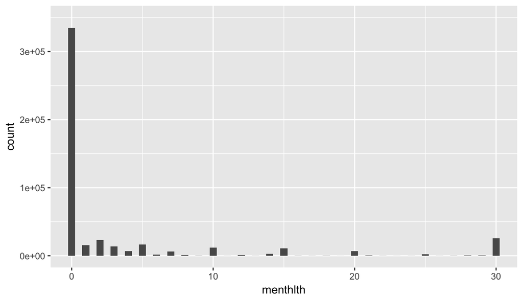

```r
ggplot(data=subset(brfss2013, !is.na(menthlth)), aes(x=menthlth)) + geom_histogram(binwidth=0.5) + coord_cartesian(xlim = c(0, 30), ylim = c(0,350000))
```

This right skew is confirmed by the histogram. Understanding the skew of the data helps us to see that this is not a normal distribution. We can then see if there are any differences with the physical health numerical variable.

### Physical Health Measures of Center

```r
brfss2013 %>% filter(!is.na(physhlth)) %>% summarise(mean_physical = mean(physhlth), median_physical = median(physhlth), sd_physical=sd(physhlth), n=n())
```

```
##   mean_physical median_physical sd_physical      n
## 1      4.352809               0     8.85473 480818
```

Again, we can see that the mean is much greater than the median. Creating another histogram, we can then view the distribution of this variable.

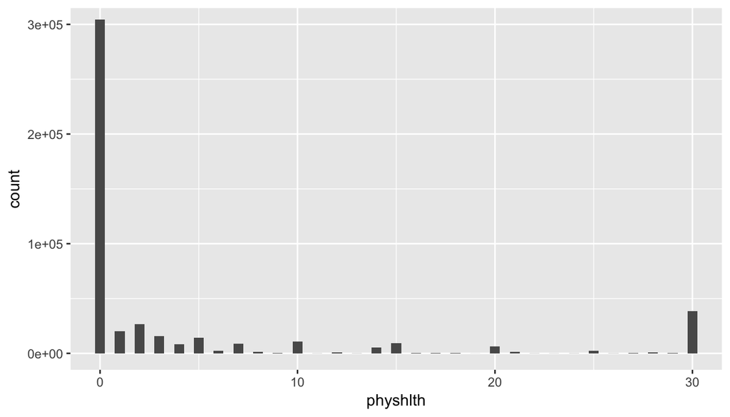

```r
ggplot(data=subset(brfss2013, !is.na(physhlth)), aes(x=physhlth)) + geom_histogram(binwidth=0.5) + coord_cartesian(xlim = c(0, 30), ylim = c(0,300000))
```

We can now confirm there is a definite right skew for the amount of not good physical and mental health days. We therefore need to use a robust statistic for understanding if the number of not good mental and physical health days differs per income type.

### Income Level, Mental and Physical Health Measures of Center

To understand how we’ll calculate this, we’ll then look at the different groupings of income type.

```r
brfss2013 %>% filter(!is.na(income2)) %>% group_by(income2) %>% summarise(count=n())
```

```
## # A tibble: 8 × 2
##             income2  count
##              <fctr>  <int>
## 1 Less than $10,000  25441
## 2 Less than $15,000  26794
## 3 Less than $20,000  34873
## 4 Less than $25,000  41732
## 5 Less than $35,000  48867
## 6 Less than $50,000  61509
## 7 Less than $75,000  65231
## 8   $75,000 or more 115902
```

First, let’s take a look at the median, mean and standard deviation for the extreme ends of this data: income of less than $10,000 and $75,000 or more, for each variable.

```r
brfss2013 %>% filter(!is.na(physhlth),!is.na(menthlth),income2 =="Less than $10,000") %>% summarise(mean_physical_ten = mean(physhlth), median_physical_ten = median(physhlth), sd_physical_ten=sd(physhlth), mean_mental_ten=mean(menthlth), median_mental_ten=median(menthlth), sf_mental_ten=sd(menthlth))
```

```
##   mean_physical_ten median_physical_ten sd_physical_ten mean_mental_ten
## 1          9.282385                   2        11.90719        7.844812
##   median_mental_ten sf_mental_ten
## 1                 0      11.25449
```

Breaking this down, we can see that there is a median of 2 not good physical health days for the income type below $10,000. There is a median of 0 for not good mental health days.

Now, let’s take a look at the other end of the spectrum; earners over $75,000.

```r
brfss2013 %>% filter(!is.na(physhlth),!is.na(menthlth),income2 =="$75,000 or more") %>% summarise(mean_physical_seven = mean(physhlth), median_physical_seven = median(physhlth),sd_physical_seven=sd(physhlth), mean_mental_seven=mean(menthlth), median_mental_seven=median(menthlth), sf_mental_seven=sd(menthlth))
```

```
##   mean_physical_seven median_physical_seven sd_physical_seven
## 1            2.078264                     0          5.838383
##   mean_mental_seven median_mental_seven sf_mental_seven
## 1          1.925643                   0        5.409041
```

Here we can see medians of 0 for both not good mental and physical health days for earners of $75,000 or more. This is different to the below $10,000 survey correspondents, indicating that those who earn less than $10,000 have a greater median of not good physical health days.

### External Variable: Median United States Household Income

While this analysis has been helpful, it is focused on the extreme ends. Following further research, we can see that in the United States, the median household income for 2013 (when this survey took place) equals $51,939 (Source: https://en.wikipedia.org/wiki/Household_income_in_the_United_States). Let’s therefore create a new variable which creates a number only version of the income bands and then another which separates survey participants into below and equals/above median income.

```r
brfss2013 <- mutate(brfss2013, income_raw=gsub("Less than|or more|\\$| ", "", brfss2013$income2))
```

```r
brfss2013 <- mutate(brfss2013,income_median= ifelse(income_raw >=51939, "Above", "Below"))
```

We can then create the same variables below and above the US median income.

```r
brfss2013 %>% filter(!is.na(physhlth),!is.na(menthlth),income_median =="Above") %>% summarise(mean_physical_above = mean(physhlth), median_physical_above = median(physhlth), sd_physical_above=sd(physhlth), mean_mental_above=mean(menthlth), median_mental_above=median(menthlth), sf_mental_above=sd(menthlth))
```

```
##   mean_physical_above median_physical_above sd_physical_above
## 1            2.366571                     0          6.302428
##   mean_mental_above median_mental_above sf_mental_above
## 1          2.120044                   0        5.749313
```

And then below:

```r
brfss2013 %>% filter(!is.na(physhlth),!is.na(menthlth),income_median =="Below") %>% summarise(mean_physical_below = mean(physhlth), median_physical_below = median(physhlth), sd_physical_below=sd(physhlth), mean_mental_below=mean(menthlth), median_mental_below=median(menthlth), sf_mental_below=sd(menthlth))
```

```
##   mean_physical_below median_physical_below sd_physical_below
## 1            5.721137                     0          9.980081
##   mean_mental_below median_mental_below sf_mental_below
## 1          4.405668                   0        8.801826
```

We can see that the medians remain the same, but there is a discrepancy in the averages for those above/below the median income. While the mean is not a robust statisic in this instance, creating a further histogram showing the distribution of not good mental and physical health days depending on whether the income is above or below the median could be valuable. I believe this is valuable as the data has already indicated a difference between income and mental and physical health, so visualising this will help us understand it further.

### Income Level Below Median & Physical Health Histogram

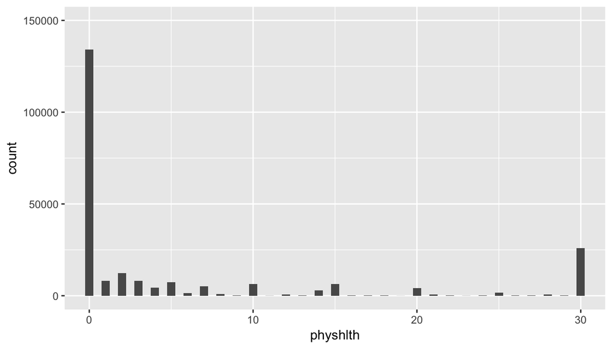

```r
ggplot(data=subset(brfss2013,income_median=="Below" & !is.na(physhlth)), aes(x=physhlth)) + geom_histogram(binwidth=0.5) + coord_cartesian(xlim = c(0, 30), ylim = c(0,150000))
```

### Income Level Above Median & Physical Health Histogram

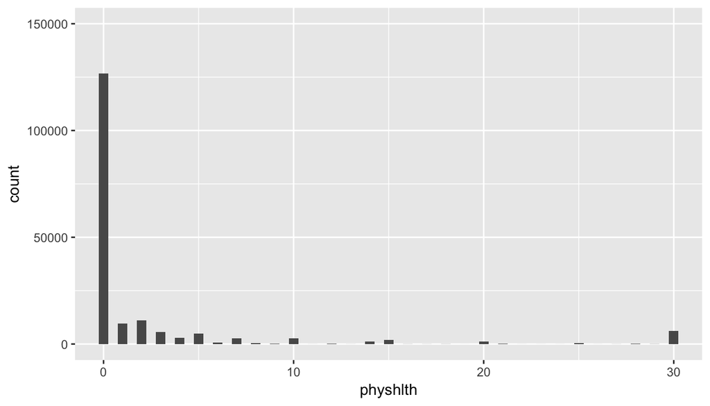

```r
ggplot(data=subset(brfss2013,income_median=="Above" & !is.na(physhlth)), aes(x=physhlth)) + geom_histogram(binwidth=0.5) + coord_cartesian(xlim = c(0, 30), ylim = c(0,150000))
```

### Income Level Below Median & Mental Health Histogram

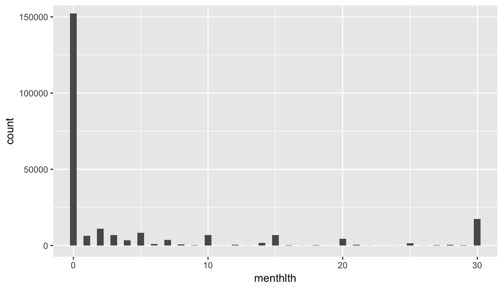

```r
ggplot(data=subset(brfss2013,income_median=="Below" & !is.na(menthlth)), aes(x=menthlth)) + geom_histogram(binwidth=0.5) + coord_cartesian(xlim = c(0, 30), ylim = c(0,150000))
```

### Income Level Above Medial & Mental Health Histogram

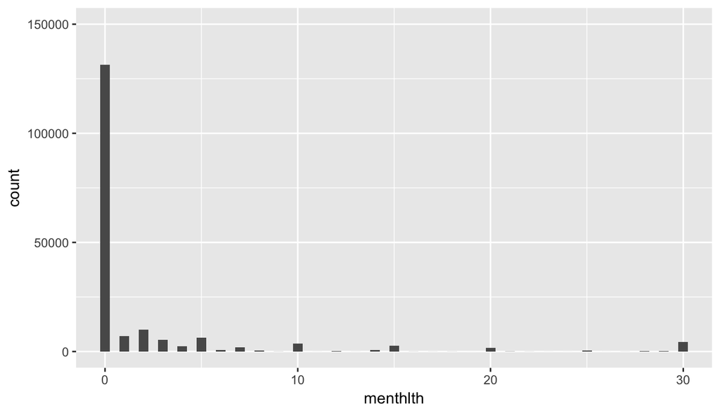

```r
ggplot(data=subset(brfss2013,income_median=="Above" & !is.na(menthlth)), aes(x=menthlth)) + geom_histogram(binwidth=0.5) + coord_cartesian(xlim = c(0, 30), ylim = c(0,150000))
```

### Probability Calculations

As a final measure, we can also take a look at the extreme end of the menthlth and physhlth measure. The probability of those Above/Below the median income will have 30 or more days of not good physical health or not good mental health. This is calculated like so:

*Physical Health Days*

```r
brfss2013 %>% group_by(income_median) %>% summarise(thirtydays = sum(physhlth >= 30 & !is.na(physhlth) & !is.na(income_median) ) / n()) %>% arrange(desc(thirtydays))
```

```
## # A tibble: 3 × 2
##   income_median thirtydays
##           <chr>      <dbl>
## 1         Below 0.10810314
## 2         Above 0.03433389
## 3          <NA> 0.00000000
```

*Mental Health Days*

```r
brfss2013 %>% group_by(income_median) %>% summarise(thirtydays = sum(menthlth >= 30 & !is.na(menthlth) & !is.na(income_median) ) / n()) %>% arrange(desc(thirtydays))
```

```
## # A tibble: 3 × 2
##   income_median thirtydays
##           <chr>      <dbl>
## 1         Below 0.07289228
## 2         Above 0.02438540
## 3          <NA> 0.00000000
```

Here we find something very interesting: We can see that participants below the median income are more likely to experience the more extreme end (>=30) of not good mental & physical health days.

Taken all together, these findings continue to show a correlation between income and days of ‘not good’ mental and physical health. While we cannot imply causation between these variables, these histograms showing distribution of values for Below/Above median incomes in the United States are certainly valuable in helping us understand the relationship between these variables.

## Research question 2:

**How much healthy food is consumed per state?**

First off, I will understand the distribution of each healthy food variable. These variables are all numerical and are:

*fruitju1: How Many Times Did You Drink 100 Percent Pure Fruit Juices?* fruit1: How Many Times Did You Eat Fruit? *fvbeans: How Many Times Did You Eat Beans Or Lentils?* fvgreen: How Many Times Did You Eat Dark Green Vegetables? *fvorang: How Many Times Did You Eat Orange-Colored Vegetables?* vegetab1: How Many Times Did You Eat Other Vegetables?

As in step 1, I can calculate the mean, median and standard deviation for each variable.

### Fruit Juice Measures of Center

*fruitju1*

```r
brfss2013 %>% filter(!is.na(fruitju1)) %>% summarise(mean_fruitju1 = mean(fruitju1), median_fruitju1 = median(fruitju1), sd_fruitjul=sd(fruitju1), n=n())
```

```
##   mean_fruitju1 median_fruitju1 sd_fruitjul      n
## 1       132.105             101    124.8713 455567
```

We can see that the mean is greater than the median, indicating a right skew. This can be confirmed with a histogram:

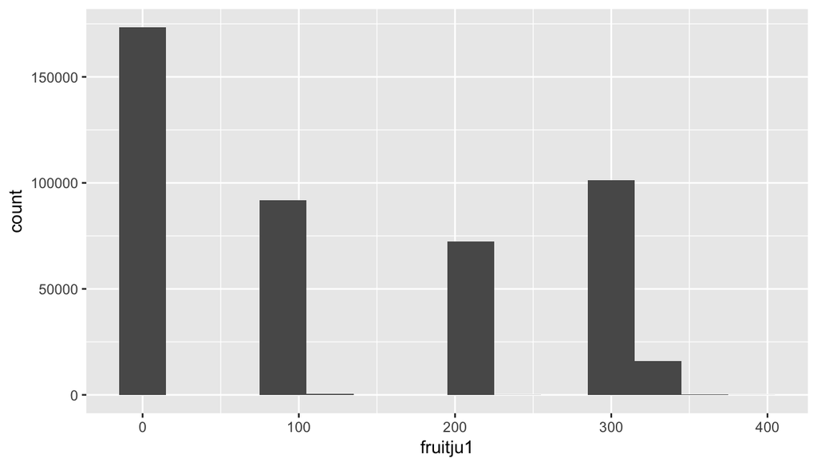

```r
ggplot(data=subset(brfss2013, !is.na(fruitju1)), aes(x=fruitju1)) + geom_histogram(binwidth=30)
```

*fruit1*

We can calculate the same for the fruit variable:

```r
brfss2013 %>% filter(!is.na(fruit1)) %>% summarise(mean_fruit1 = mean(fruit1), median_fruit1 = median(fruit1), sd_fruit=sd(fruit1), n=n())
```

```
##   mean_fruit1 median_fruit1 sd_fruit      n
## 1    178.7894           110 95.72444 457977
```

Again, another right skew is suspected here, which can be confirmed with a histogram

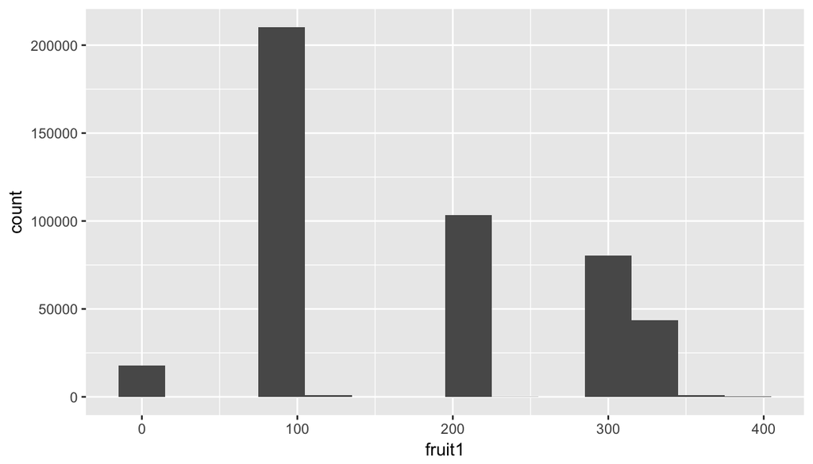

```r
ggplot(data=subset(brfss2013, !is.na(fruit1)), aes(x=fruit1)) + geom_histogram(binwidth=30)
```

As there are several variables, we can quickly calculate the measures of center for each one:

*fvbeans*

```r
brfss2013 %>% filter(!is.na(fvbeans)) %>% summarise(mean_fvbeans = mean(fvbeans), median_fvbeans = median(fvbeans), sd_fvbeans=sd(fvbeans), n=n())
```

```
##   mean_fvbeans median_fvbeans sd_fvbeans      n
## 1     208.4711            203   111.5915 454283
```

*fvgreen*

```r
brfss2013 %>% filter(!is.na(fvgreen)) %>% summarise(mean_fvgreen = mean(fvgreen), median_fvgreens = median(fvgreen), sd_fvgreens=sd(fvgreen), n=n())
```

```
##   mean_fvgreen median_fvgreens sd_fvgreens      n
## 1     208.0313             203    98.08457 456618
```

*fvorang*

```r
brfss2013 %>% filter(!is.na(fvorang)) %>% summarise(mean_fvorang = mean(fvorang), median_fvorang = median(fvorang), sd_fvorang=sd(fvorang), n=n())
```

```
##   mean_fvorang median_fvorang sd_fvorang      n
## 1     211.8568            203   106.5956 455212
```

*vegetab1*

```r
brfss2013 %>% filter(!is.na(vegetab1)) %>% summarise(mean_vegetab = mean(vegetab1), median_vegetab = median(vegetab1), sd_vegetab=sd(vegetab1), n=n())
```

```
##   mean_vegetab median_vegetab sd_vegetab      n
## 1     203.4821            203   92.71882 452828
```

Interestingly, we can see a much closer match between the median and the mean, so it is worthwhile creating a histogram of this data:

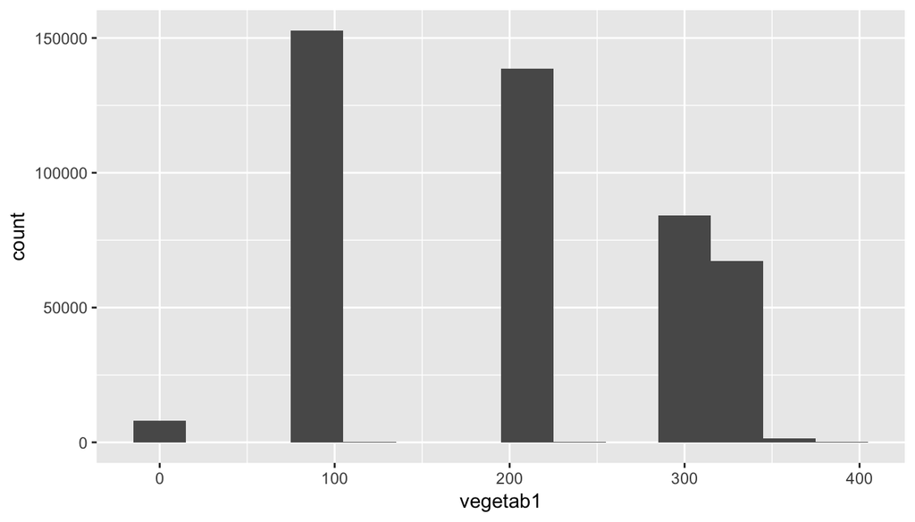

```r
ggplot(data=subset(brfss2013, !is.na(vegetab1)), aes(x=vegetab1)) + geom_histogram(binwidth=30)
```

Now we have assessed the individual variables, we can then create a view of the amount of healthy food eaten, per state:

```r
brfss2013 %>% group_by(X_state) %>% summarise(healthfoodtotal = sum(fruitju1+fruit1+fvbeans+fvorang+vegetab1 & !is.na(fruitju1) & !is.na(fruit1)  & !is.na(fvbeans) & !is.na(fvorang) & !is.na(vegetab1))) %>% arrange(desc(healthfoodtotal))
```

```
## # A tibble: 55 × 2
##          X_state healthfoodtotal
##           <fctr>           <int>
## 1        Florida           29245
## 2         Kansas           21079
## 3       Nebraska           15497
## 4  Massachusetts           13025
## 5      Minnesota           12795
## 6       Colorado           11791
## 7     New Jersey           11713
## 8       Michigan           11701
## 9           Utah           11414
## 10      Maryland           11403
## # ... with 45 more rows
```

We can see here that Florida eats the most amount of healthy food. Going forward, we could create a density map to understand this further, and create a ratio of healthy food per person in state, but for now we have answered our research question of the most amount of healthy food consumed per state.

## Research question 3:

**What is the average amount of adults per household, per state?**

For this research question, we will be using the following variables:

- _State: a categorical variable, State Fips code
- numadult: a numeric variable, Number Of Adults In Household

On the face of it, this is relatively simple question to answer, as we simply need to calculate the average amount of number of adults in household, per state:

```r
brfss2013 %>% group_by(X_state) %>% filter(!is.na(numadult)) %>% summarise(mean_numadult = mean(as.numeric(numadult))) %>% arrange(desc(mean_numadult))
```

```
## # A tibble: 53 × 2
##        X_state mean_numadult
##         <fctr>         <dbl>
## 1         Guam      2.419576
## 2         Utah      2.022454
## 3  Puerto Rico      1.998307
## 4       Hawaii      1.985976
## 5   California      1.924261
## 6   New Jersey      1.904460
## 7       Alaska      1.879235
## 8     Kentucky      1.876418
## 9     Illinois      1.859602
## 10       Texas      1.851417
## # ... with 43 more rows
```

We have stated in the research question that we want to find the ‘average’, but perhaps we also need to consider whether the average is a robust statistic. To understand this, we can calculate the Measures of Center for this numeric variable.

### Number of Adults per Household Measures of Center

```r
brfss2013 %>% filter(!is.na(numadult)) %>% summarise(mean_numadult = mean(as.numeric(numadult)), median_numadult=median(as.numeric(numadult)), sd_adult=sd(as.numeric(numadult)))
```

```
##   mean_numadult median_numadult  sd_adult
## 1      1.809402               2 0.7901121
```

The median and average are quite close and we can also confirm this by plotting the data. However, unlike the earlier questions, this numeric variable is *discrete*, not continuous, so we’ll actually plot a bar chart. This is confirmed by ggplot, as when we try to create a histogram, we receive a warning. We’ll therefore opt for a bar chart:

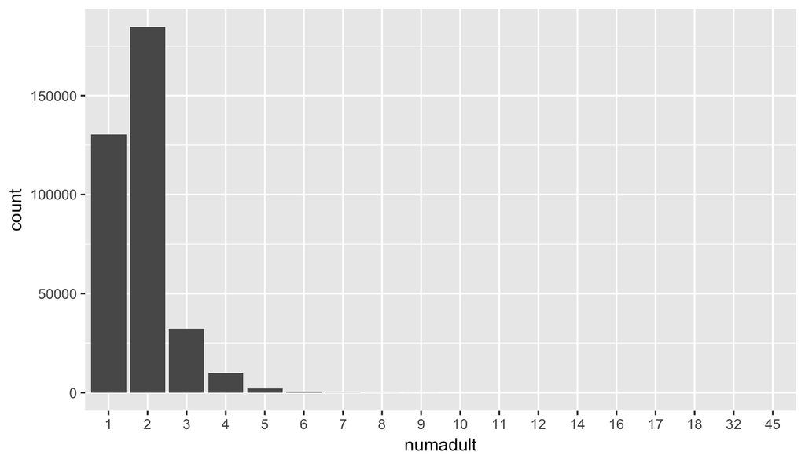

```r
ggplot(data=subset(brfss2013, !is.na(numadult)), aes(x=numadult)) + geom_bar()
```

Given that the median and average are close, we can feel relatively confident using an average.